# Jane Eyre exercise

2023-02-02

Set the working directory and scan the file from disk or retrieve over the web.

```r
setwd("D:/1.CollegeEducation/3.Sophomore/Spring2023/is310/TextAnalysisWithR/data/plainText")
text.v <- scan("jane.txt", what="character", sep="\n")
```

The variable text.v is a vector of strings, the file having been read one line at a time.

These regular expressions should work with Project Gutenberg files for finding the start an end of the text:

- Three literal asterisk characters,
- followed by zero or more non-word (i.e, white space) characters,
- followed by “START OF TH” or “END OF TH”.
- The backslash character is a reserved escape character in R strings, so we use two of them for a literal backslash.

```r
start.v <- (grep("\\*\\*\\*\\W*START OF TH",text.v) + 1)
end.v <- grep("\\*\\*\\*\\W*END OF TH",text.v)
```

Vectors in R can be indexed one element at a time, like ‘foo.v[6]’ or a group of elements via a range like ‘foo.v[6:20]’. We can use variables, as shown below and their values will be substituted.

```r
start.metadata.v <- text.v[1:start.v -1]
end.metadata.v <- text.v[(end.v):length(text.v)]
metadata.v <- c(start.metadata.v, end.metadata.v)
novel.lines.v <-  text.v[start.v:(end.v-1)]
```

Collapse all the lines of the novel into one long string. Put a space where the line breaks had been. Convert the whole novel into lower case.

```r
novel.v <- paste(novel.lines.v, collapse=" ")
novel.lower.v <- tolower(novel.v)
```

```r
jane.words.l <- strsplit(novel.lower.v, "\\W")
jane.word.v <- unlist(jane.words.l)
```

Vectors give us powerful operations like “return a vector of element numbers where the string elements of this vector aren’t blank.” Then: “use that resulting numeric vector as indices and replace my vector of words entirely with a version that omits the empty strings.’

```r
not.blanks.v  <-  which(jane.word.v!="")
jane.word.v <-  jane.word.v[not.blanks.v]
```

The ‘which’ command can also return an entire vector of values where the element we’re looking for is repeated. The length of that vector gives us the number of occurrences.

```r
love.hits.v <- length(jane.word.v[which(jane.word.v=="love")])
total.words.v <- length(jane.word.v)
```

Create a frequency table for the words in the novel. Sort that table in decreasing order. Divide the entries by the novel length (measured in words) and multiply by 100 to give percentages. Plot those numbers.

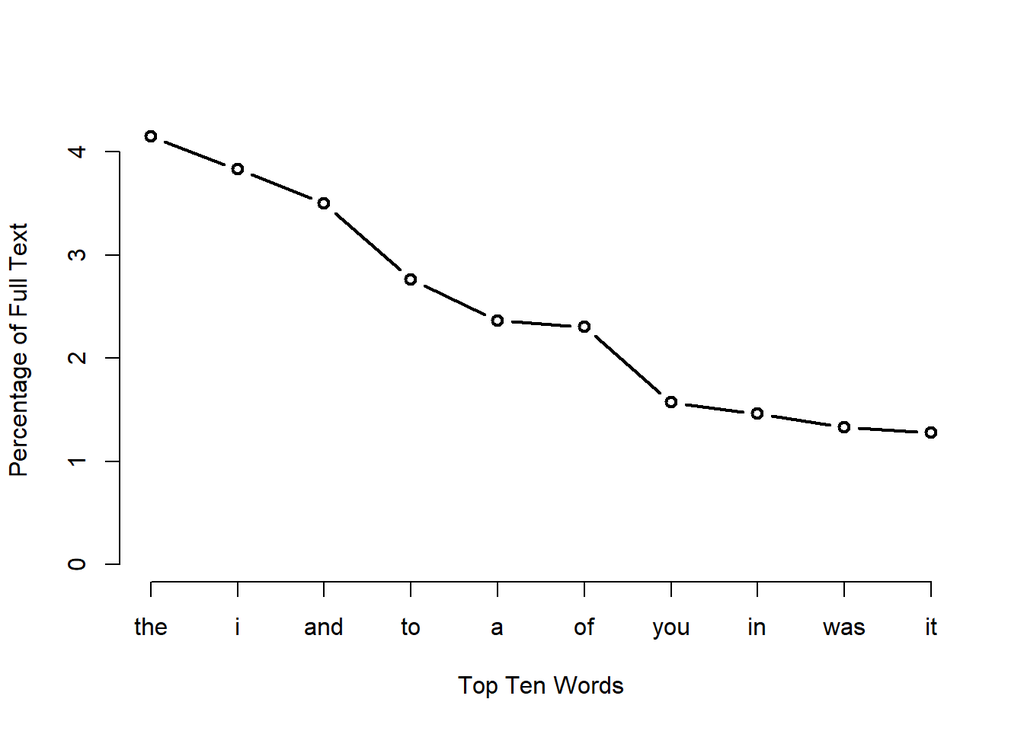

```r
jane.freqs.t <- table(jane.word.v)
sorted.jane.freqs.t <- sort(jane.freqs.t , decreasing=TRUE)

sorted.jane.rel.freqs.t <- 100*(sorted.jane.freqs.t/sum(sorted.jane.freqs.t))

plot(sorted.jane.rel.freqs.t[1:10], type="b",
     xlab="Top Ten Words", ylab="Percentage of Full Text", xaxt ="n")
axis(1,1:10, labels=names(sorted.jane.rel.freqs.t [1:10]))
```

```r
chapters.v <- grep("*CHAPTER*", text.v)
chapters <- c(chapters.v, end.v)
chapters.lines <- c()
for (i in 2: length(chapters.v) - 1) {

  chapters.lines <- c( chapters.lines , paste(text.v[chapters.v[i] + 1: chapters.v[i + 1]], collapse=" "))

}
```

```r
chapters.lines[1]
```

```
## [1] "There was no possibility of taking a walk that day. We had been wandering, indeed, in the leafless shrubbery an hour in the morning; but since dinner (Mrs. Reed, when there was no company, dined early) the cold winter wind had brought with it clouds so sombre, and a rain so penetrating, that…
```

```r
chapters.lines[2]
```

```
## [1] "I resisted all the way: a new thing for me, and a circumstance which greatly strengthened the bad opinion Bessie and Miss Abbot were disposed to entertain of me. The fact is, I was a trifle beside myself; or rather _out_ of myself, as the French would say: I was conscious that a moment’s mut…
```